```
import pandas as pd
from pandas.tseries import offsets
import numpy as np
import datetime as dt
import yaml
import matplotlib.pyplot as plt
from matplotlib.pyplot import cm
import matplotlib.ticker as mtick
from matplotlib.ticker import (MultipleLocator, FormatStrFormatter,
                               AutoMinorLocator, NullLocator)
import matplotlib.dates as mdates
import seaborn as sns
```

# Data Sources on Use of Solitary Confinement at Northwest ICE Processing Center

## UW Center for Human Rights

Data analyzed:

1. Dataset of solitary confinement placements at NWDC released to UWCHR via FOIA on February 22, 2019
2. Dataset of national solitary confinement placements in ICE detention analyzed by International Consortium of Investigative Journalists (Spencer Woodman, Karrie Kehoe, Maryam Saleh, and Hannah Rappleye, "Thousands of Immigrants Suffer In US Solitary Confinement", ICIJ, May 21 2019)
3. Dataset of national solitary confinement placements in ICE detention analyzed by Project on Government Oversight (POGO, ["ISOLATED: ICE Confines Some Detainees with Mental Illness in Solitary for Months"](https://www.pogo.org/investigation/2019/08/isolated-ice-confines-some-detainees-with-mental-illness-in-solitary-for-months/), August 14 2019)
4. Dataset of characteristics of ICE detention facilities obtained via FOIA by National Immigrant Justice Center (NIJC, [" ICE Detention Facilities As Of November 2017"](https://immigrantjustice.org/ice-detention-facilities-november-2017))

```
csv_opts = {'sep': '|',
            'quotechar': '"',
            'compression': 'gzip',
            'encoding': 'utf-8'}

# Import and test asserts for UWCHR segregation log dataset
uwchr = pd.read_csv('input/srms-1.csv.gz',
                 parse_dates=['placement_date', 'release_date'],
                 **csv_opts)

assert len(uwchr[uwchr['release_date'] < uwchr['placement_date']]) == 0
assert len(uwchr) == len(set(uwchr['tracking_number']))
assert sum(uwchr['placement_date'].isnull()) == 0

# Import ICIJ segregation log dataset
icij = pd.read_csv('input/icij.csv.gz',
                   parse_dates=['placement_date', 'release_date'],
                   **csv_opts)
icij['facility'] = icij['facility'].str.strip()
icij_nwdc_str = 'WA - Northwest Detention Center'
icij_nwdc = icij['facility'] == icij_nwdc_str
icij_adelanto = icij['facility'] == 'CA - Adelanto Correctional Facility'

# Import POGO segregation log dataset
pogo = pd.read_csv('input/pogo.csv.gz',
                   parse_dates=['placement_date', 'release_date'],
                   **csv_opts)

pogo['record_id'] = range(len(pogo))
pogo = pogo.rename({'length_of_solitary_confinement_(pogo_calculation)': 'days_solitary'}, axis=1)
pogo_nwdc_str = 'TACOMA ICE PROCESSING CENTER (NORTHWEST DET CTR) (WA)'
pogo_nwdc = pogo['facility'] == pogo_nwdc_str
pogo['nwdc'] = pogo['facility'] == pogo_nwdc_str

# Import NIJC facilities dataset
facil = pd.read_csv('frozen/facil-list.csv.gz', **csv_opts)
```

## Data Quality

Previous reports by ICIJ and POGO analyzing ICE solitary confinement data have noted that the data likely under-reports true total solitary confinement placements, either due to inaccurate record-keeping or limited criteria for cases which are recorded by ICE. In correspondence related to UWCHR's FOIA litigation against ICE, counsel for DHS has confirmed that the dataset released to UWCHR is drawn from ICE's "Segregation Review Management System" (SRMS), asserting that "Only certain categories of segregation are required to be reported to ICE." A 2017 DHS Office of the Inspector General report explains, "According to SRMS guidance, ERO field office staff, including FODs, must use SRMS to report segregation placement data that falls under the ICE directive’s reporting requirements." These requirements include segregation placements affecting people with "special vulnerabilities" including mental health diagnoses; and placements exceeding 14 days during any 21-day period.<sup>[1]</sup> However, elsewhere ICE has stated "SRMS provides a centralized historical record of all segregation cases".<sup>[2]</sup>

### Comparisons of SRMS data with published government reports

A comparison of SRMS data released via FOIA with other government sources noting total segregation placement counts suggests that under-reporting of segregation placements may be extensive. For example, SRMS data released to UWCHR under FOIA reports 106 total segregation placements from June 2013-June 2014. However, a [June 24-26, 2014 Office of Detention Oversight inspection report for NWDC](https://drive.google.com/file/d/1YDX4fOOJ3DCftWiQv7O_5jwA2eZ0ftWR/view?usp=sharing) cdstates, “Documentation reflects there were 776 assignments to segregation in the past year: 515 to administrative segregation and 261 to disciplinary segregation” (page 27). Similarly, data on administrative and disciplinary segregation placements nationwide released under FOIA and published by the International Consortium of Investigative Journalists reports 222 total segregation placements at Adelanto Detention Facility in Adelanto, CA from July 2013-July 2014. However, a [July 8-10, 2014 Office of Detention Oversight inspection of Adelanto](https://www.ice.gov/doclib/foia/odo-compliance-inspections/2014AdelantoJuly.pdf) reports 286 administrative segregation and 328 disciplinary segregation placements (a total of 614) during the year prior to the inspection. Similar reports do not appear to be available for more recent years.

Another source of government data offering a comparison with SRMS records is a 2017 DHS Office of Inspector General report [ICE Field Offices Need to Improve Compliance with Oversight Requirements for Segregation of Detainees with Mental Health Conditions](https://www.oig.dhs.gov/sites/default/files/assets/2017-11/OIG-17-119-Sep17.pdf), which noted issues with segregation reporting.<sup>[3]</sup> The report's methodology is described as follows:

"We [...] analyzed SRMS data from October 1, 2015, to June 30, 2016, which showed 713 segregation placements for detainees with mental health conditions — 272 disciplinary instances and 441 administrative instances. Some detainees were segregated multiple times. From the 713 segregation placements in this time period that were in SRMS, we selected and reviewed a judgmental sample of 189 instances of segregation involving 127 detainees with mental health conditions."

We can use national SRMS logs covering this time period, released by the Project on Government Oversight, to attempt to replicate this methodology:

```
oig_frame_start = '2015-10-01'
oig_frame_end = '2016-06-30'

oig_frame = pogo.set_index('placement_date')[oig_frame_start:oig_frame_end]

mental_illness_true = ['Yes', 'Mental Illness', 'Serious Mental Illness']
```

Nationwide, during the period analyzed by the DHS OIG, the POGO dataset includes 511 SRMS records indicating mental illness; fewer than reported by the DHS OIG.

These examples suggest that not only do the SRMS logs significantly under-count total segregation placements, SRMS logs released by ICE may not be complete.

## Dataset Structure and Cleaning Process

In a separate process, the document released by ICE (`2018-ICFO-00515 Highlighted_EDIT.xlsx`) has been edited to remove fields containing unredacted sensitive and personally-identifiable information; converted to CSV format and compressed. The resulting file, `2018-ICFO-00515 Highlighted_PUBLIC.csv.gz`, after cleaning and standardization documented in [`clean/`](https://github.com/UWCHR/nwdc-seg/tree/master/clean), is described and analyzed in the continuing sections.

## Dataset Description and Analysis

The dataset released to UWCHR includes 371 records of solitary confinement placements at the Northwest Detention Center. Each record relates to a specific solitary confinement "placement". Detainee names, A-numbers, are redacted from the dataset, making it impossible to determine whether any records relate to detainees experiencing multiple solitary confinement placements; however, comment fields excluded from the public version of this dataset make clear that some represent repeat placements.

The earliest placement date (start of solitary stay) was May 13, 2013 and the latest placement date was May 20, 2018. The earliest release date (end of solitary stay) was July 16, 2013 and the latest release date was May 31, 2018.

No month during the period included in the dataset had fewer than 2 solitary placements. The maximum number of solitary confinement placements in a single month was 18 in December 2013. The overall average number of solitary placements per month was 6.08.

**Figure 1: Total monthly solitary confinement placements at NWDC**

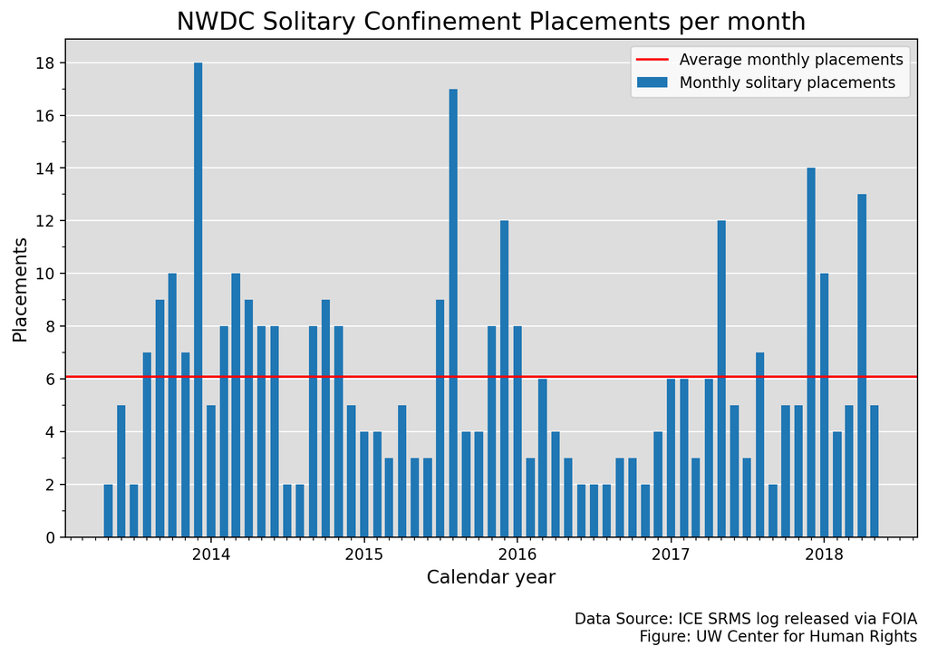

340 people placed in solitary were male, 31 were female. People placed in solitary confinement at NWDC were from 55 countries. The top 5 countries of citizenship are listed in Table 1 below.

**Table 1: Top five countries of citizenship of detainees placed in solitary confinement at NWDC**

| Country of Citizenship | NWDC Solitary Placements |
| --- | --- |
| Mexico | 194 |
| Canada | 20 |
| Guatemala | 18 |
| El Salvador | 17 |
| Somalia | 13 |
| All Others | 109 |

### Length of Segregation Placements

14 records do not have a "Release Date" specified. All of these records are segregation placements beginning during the latter portion of the dataset, which suggests that these refer to individuals who remained in segregation at the time of production of this dataset.<sup>[4]</sup> For purposes of analysis of placement length, we exclude these records, leaving 357 completed solitary placements.

The maximum completed segregation placement length was 781 days. The average segregation placement length was 59.61 days and the median Segregation placement length was 30 days. The most common placement length was 32 days.

The median and mode values are close to ICE's maximum length of 30 days for most disciplinary segregation placements.<sup>[5]</sup> 50.14% of placements were for 30 days or less, and 49.86% of placements were for more than 30 days.

67, or 18.77% of placements were for 15 days or less, and 290, or 81.23% of placements were for more than 15 days. Under the United Nations Standard Minimum Rules for the Treatment of Prisoners, segregation for more than 15 consecutive days is prohibited. Note that ICE regulations do not require reporting of all segregation placements, as described above.

The following histogram chart displays the distribution of length of stay for completed segregation placements (excluding outliers).

**Figure 2: Distribution of length of completed segregation placements (`days_solitary`) at NWDC**

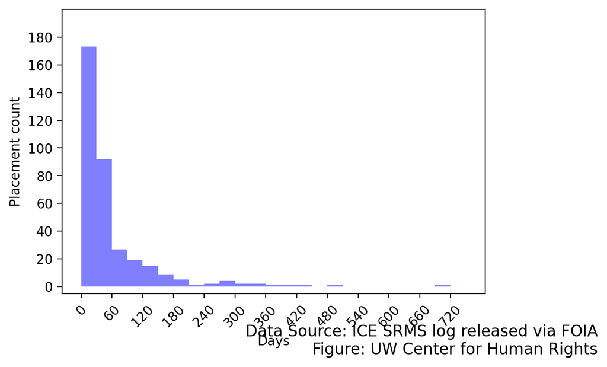

### Placement Reason

Each solitary placement is categorized with one of 16 placement reasons (including "Other"). As mentioned above, the maximum solitary length for most "Disciplinary" placements is 30 days.

We can also aggregate these placement reasons into broader categories for comparison, as in the following figure:

**Figure 3: Distribution of variable** `days_solitary` **by** `placement_reason_type`

```
Text(1.1, -0.03, 'Data Source: ICE SRMS log released via
FOIA\nFigure: UW Center for Human Rights')
```

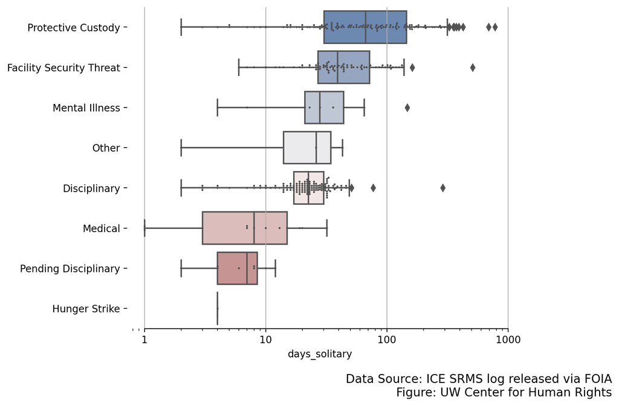

As seen in the following table describing the lenth of solitary placement for each detailed placement type, the most frequently used reasons include broad categories such as "Disciplinary", "Protective Custody: Other Detainee Safety" and "Facility Security Threat: Other".

**Table 2: Description of variable** `days_solitary` **grouped by** `placement_reason`

| placement_reason | count | mean | std | min | 25% | 50% | 75% | max |
| --- | --- | --- | --- | --- | --- | --- | --- | --- |
| Disciplinary | 128 | 25.52 | 25.84 | 2 | 17.00 | 22.5 | 30.00 | 288 |
| Protective Custody: Other Detainee Safety | 81 | 92.37 | 106.72 | 2 | 27.00 | 59.0 | 121.00 | 691 |
| Facility Security Threat: Other | 33 | 55.00 | 40.28 | 12 | 27.00 | 36.0 | 86.00 | 162 |
| Protective Custody: Gang Status (Protective Custody Only) | 25 | 138.92 | 129.96 | 4 | 39.00 | 83.0 | 207.00 | 423 |
| Facility Security Threat: Violent or Disruptive Behavior | 23 | 54.78 | 36.46 | 6 | 30.00 | 44.0 | 82.50 | 133 |
| Facility Security Threat: Gang Member Status (Not Protective Custody) | 19 | 68.53 | 110.71 | 7 | 28.50 | 34.0 | 61.50 | 509 |
| Medical: Observation | 9 | 8.78 | 7.56 | 1 | 1.00 | 7.0 | 15.00 | 20 |
| Mental Illness | 9 | 41.67 | 43.67 | 4 | 21.00 | 28.0 | 44.00 | 147 |
| Pending Investigation of Disciplinary Violation | 8 | 6.75 | 3.37 | 2 | 4.00 | 7.0 | 8.50 | 12 |
| Protective Custody: Criminal Offense (i.e. Sex Offender) | 8 | 217.75 | 234.76 | 39 | 118.00 | 144.0 | 177.50 | 781 |
| Medical: Other | 4 | 14.50 | 12.4 | 3 | 8.25 | 11.5 | 17.75 | 32 |
| Other | 3 | 23.67 | 20.6 | 2 | 14.00 | 26.0 | 34.50 | 43 |
| Protective Custody: Special Vulnerability Other | 3 | 26.67 | 17.04 | 9 | 18.50 | 28.0 | 35.50 | 43 |
| Facility Security Threat: Due to Seriousness of Criminal Conviction | 2 | 50.00 | 25.46 | 32 | 41.00 | 50.0 | 59.00 | 68 |
| Hunger Strike | 1 | 4.00 |  | 4 | 4.00 | 4.0 | 4.00 | 4 |
| Protective Custody: Lesbian, Gay, Bisexual, Transgender (LGBT) | 1 | 118.00 |  | 118 | 118.00 | 118.0 | 118.00 | 118 |

Application of different placement reason categories varies over time, as seen in the following figure, which shows trends in the proportion of placement reasons per fiscal year period:

[output not shown]

**Figure 5: NWDC segregation placements by reason and stay length over time**

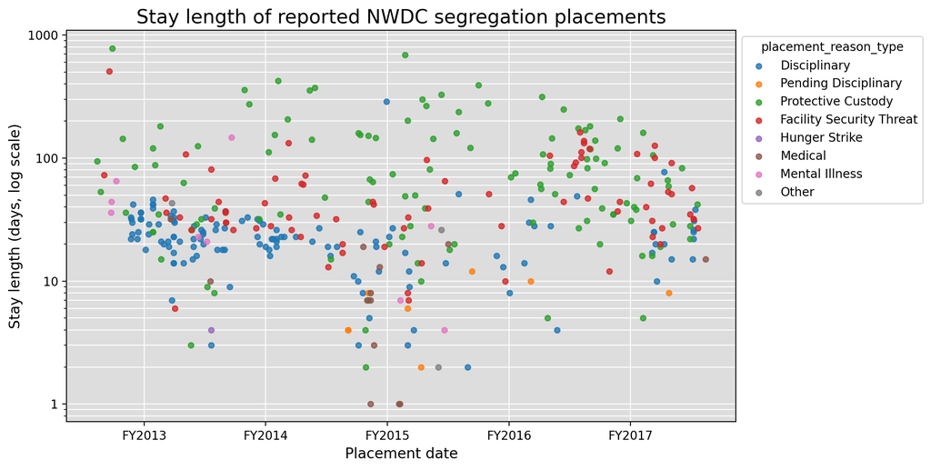

### Mental illness

While "Mental Illness" is occasionally employed as a `placement_reason` value, all records also include a `mental_illness` field indicating whether the detained person has been diagnosed with a mental illness or serious mental illness. 116, or 31.27% of records indicate a "Mental Illness" diagnosis; 18, or 4.85% of records indicate a diagnosis of "Serious Mental Illness". Remaining records indicate no mental illness diagnosis.

As shown in the preceding section, 9 records indicate a `placement_reason` of "Mental Illness". Of these records, 3 indicate a `mental_illness` value of "None".

As illustrated in the following table and chart, stay lengths for individuals with a "Mental Illness" diagnosis tended to be shorter than those without. However, stay lengths for individuals with a "Serious Mental Illness" diagnosis tended to be longer:

| mental_illness | count | mean | std | min | 25% | 50% | 75% | max |
| --- | --- | --- | --- | --- | --- | --- | --- | --- |
| None | 228 | 61.63 | 91.17 | 1 | 22.00 | 31.5 | 62.00 | 781 |
| Mental Illness | 111 | 49.11 | 80.81 | 1 | 8.00 | 20.0 | 50.50 | 509 |
| Serious Mental Illness | 18 | 98.67 | 86.69 | 5 | 52.25 | 86.0 | 110.75 | 327 |

**Figure 6: Distribution of variable** `days_solitary` **by** `mental_illness`

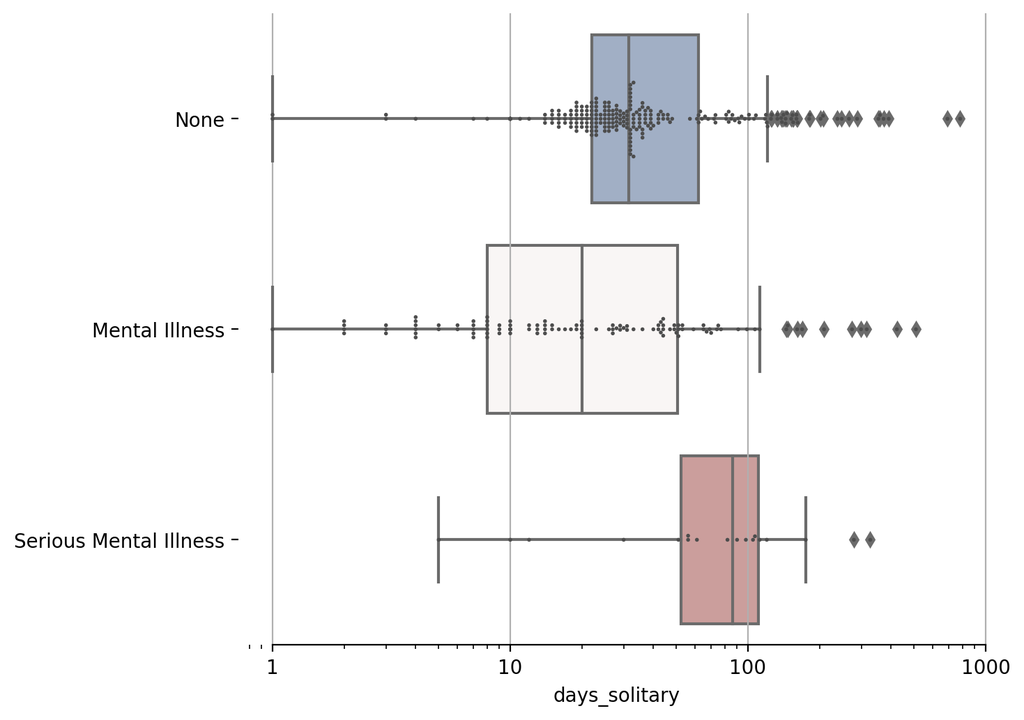

### "Facility-Initiated" versus "Detainee Request" placements at NWDC

Each placement is coded as either "Facility-Initiated" (264 placements) or "Detainee Request" (107 placements). As seen in the below table, the majority of reported detainee requested placements were for "Protective Custody", with a small minority classified as "Other."

Average stay lengths for "Detainee Request" placements were considerably longer than for "Facility-Initiated" placements (118.99 versus 36.18) days; however, we note that stay lengths vary greatly and fluctuate over time, as seen in the following figure.

[output not shown]

[output not shown]

### POGO

See: POGO, ["ISOLATED: ICE Confines Some Detainees with Mental Illness in Solitary for Months"](https://www.pogo.org/investigation/2019/08/isolated-ice-confines-some-detainees-with-mental-illness-in-solitary-for-months/), August 14, 2019.

The dataset published by POGO includes 149 solitary confinement placements at NWDC from January 1, 2016 to May 4, 2018, out of a total of 6559 placements nationwide.

NWDC is ranked #13 among 99 ICE facilities ranked by number of solitary placements. The average length of solitary stay is almost 69.88 days (rank #2), compared to a national average of 30.2; median solitary stay is 42.0 days at NWDC (rank #6), compared to a national median of 20.0.

The following table describes the distribution of solitary placement lengths (`solitary_days`) for the top 10 facilities with the longest average solitary placements. Note that some of the top facilities only have very few total placements during the period described by the POGO data.

**Table 5: Top 10 immigration detention facilities by average solitary placement length, description of variable `days_solitary`**

| facility | count | mean | std | min | 25% | 50% | 75% | max |
| --- | --- | --- | --- | --- | --- | --- | --- | --- |
| BUTLER COUNTY JAIL (KS) | 2 | 74 | 24.04 | 57 | 65.5 | 74 | 82.5 | 91 |
| TACOMA ICE PROCESSING CENTER (NORTHWEST DET CTR) (WA) | 139 | 69.88 | 72.58 | 2 | 22.5 | 42 | 94.5 | 391 |
| UTAH COUNTY JAIL (UT) | 9 | 67.11 | 57.18 | 3 | 16 | 68 | 105 | 172 |
| YUBA COUNTY JAIL (CA) | 58 | 65.43 | 81.5 | 1 | 18.5 | 32 | 73.5 | 413 |
| NORTHERN OREGON CORRECTIONAL FACILITY (OR) | 4 | 60.75 | 76.69 | 10 | 24.25 | 29 | 65.5 | 175 |
| BOONE COUNTY JAIL (KY) | 1 | 57 |  | 57 | 57 | 57 | 57 | 57 |
| WORCESTER COUNTY JAIL (MD) | 10 | 56 | 28.31 | 22 | 32.25 | 52 | 81 | 97 |
| ATLANTA CITY DETENTION CENTER (GA) | 35 | 53.94 | 72.97 | 3 | 16 | 24 | 60.5 | 352 |
| RIO COSUMNES CORR. CENTER (CA) | 40 | 52.65 | 46.26 | 4 | 19.75 | 33.5 | 66 | 167 |
| SENECA COUNTY JAIL (OH) | 25 | 52.04 | 115.31 | 1 | 8 | 22 | 36 | 587 |

**Figure 8: Top 15 immigration detention facilities by total number of solitary placements, average solitary placement length per quarter**

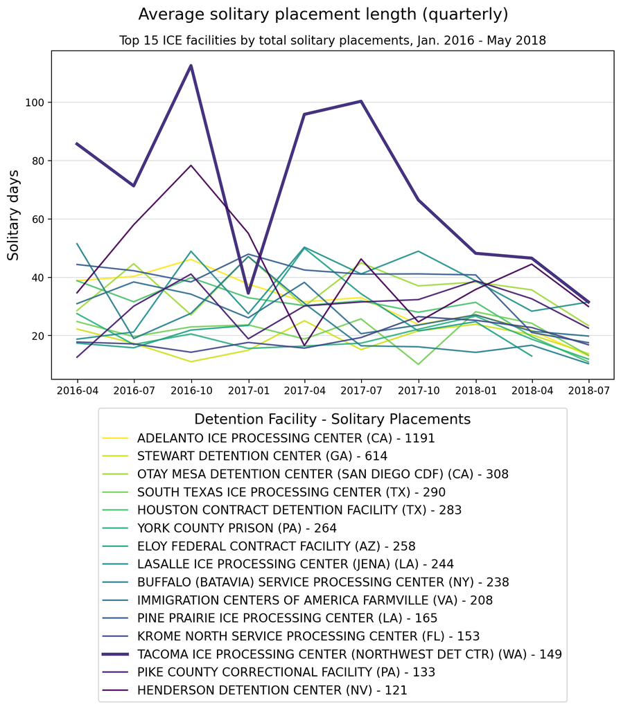

#### National comparison of solitary stay length by placement categories

Average solitary stays at NWDC are longer than other facilities for both "detainee request" and "facility-initiated" placements:

**Table 6: Solitary placements groupbed by `detainee_request`, NWDC ('True') versus all other facilities, description of variable `days_solitary`**

| nwdc | detainee_request | count | mean | std | min | 25% | 50% | 75% | max |
| --- | --- | --- | --- | --- | --- | --- | --- | --- | --- |
| False | Detainee Request | 1351 | 50.28 | 64.44 | 0.0 | 15.00 | 30.0 | 60.00 | 790.0 |
|  | Facility-Initiated | 4949 | 23.60 | 27.15 | 0.0 | 8.00 | 19.0 | 29.00 | 466.0 |
| True | Detainee Request | 58 | 103.33 | 92.27 | 5.0 | 38.25 | 74.0 | 142.75 | 391.0 |
|  | Facility-Initiated | 81 | 45.94 | 40.35 | 2.0 | 17.00 | 31.0 | 57.00 | 175.0 |

Placement reason categories longer on average at NWDC than at other detention facilities nationwide include "Facility Security Threat", "Medical", and "Protective Custody". We note that no solitary placements at NWDC are classified as "Suicide Risk Placement".

**Table 7: Solitary placements grouped by `placement_reason_type`, NWDC ('True') versus all other facilities, description of variable `days_solitary`**

| nwdc | placement_reason_type | count | mean | std | min | 25% | 50% | 75% | max |
| --- | --- | --- | --- | --- | --- | --- | --- | --- | --- |
| False | Disciplinary | 2776 | 23.70 | 16.39 | 0.0 | 15.0 | 21.0 | 29.00 | 303.0 |
|  | Facility Security Threat | 556 | 45.16 | 45.07 | 0.0 | 19.0 | 31.0 | 55.00 | 330.0 |
|  | Hunger Strike | 225 | 6.40 | 14.89 | 0.0 | 3.0 | 4.0 | 7.00 | 219.0 |
|  | Medical | 264 | 10.21 | 14.64 | 0.0 | 1.0 | 5.0 | 13.25 | 112.0 |
|  | Mental Illness | 145 | 21.79 | 27.10 | 0.0 | 5.0 | 12.0 | 28.00 | 164.0 |
|  | Other | 49 | 29.65 | 27.99 | 1.0 | 10.0 | 22.0 | 45.00 | 133.0 |
|  | Pending Disciplinary | 365 | 7.26 | 18.87 | 0.0 | 3.0 | 4.0 | 7.00 | 287.0 |
|  | Protective Custody | 1636 | 49.50 | 62.00 | 0.0 | 16.0 | 30.0 | 60.00 | 790.0 |
|  | Suicide Risk Placement | 284 | 5.04 | 6.54 | 0.0 | 1.0 | 3.0 | 6.00 | 45.0 |
| True | Disciplinary | 27 | 24.78 | 16.31 | 2.0 | 14.5 | 22.0 | 29.00 | 77.0 |
|  | Facility Security Threat | 38 | 64.53 | 40.84 | 10.0 | 32.0 | 51.0 | 100.00 | 162.0 |
|  | Medical | 1 | 20.00 | NaN | 20.0 | 20.0 | 20.0 | 20.00 | 20.0 |
|  | Mental Illness | 2 | 16.00 | 16.97 | 4.0 | 10.0 | 16.0 | 22.00 | 28.0 |
|  | Other | 2 | 14.00 | 16.97 | 2.0 | 8.0 | 14.0 | 20.00 | 26.0 |
|  | Pending Disciplinary | 4 | 8.00 | 4.32 | 2.0 | 6.5 | 9.0 | 10.50 | 12.0 |
|  | Protective Custody | 65 | 99.71 | 89.61 | 5.0 | 35.0 | 73.0 | 139.00 | 391.0 |

### Facility average length of stay

Long solitary stays at NWDC cannot be separated from the broader issue of prolonged, and lengthening, stays in civil immigration detention. According to data released by ICE, the average length of stay at NWDC increased from 82 days in FY2015 to 97 days in FY2018. During the period from FY2015-2018 average stay lengths at NWDC were longer than at 93.0% of other immigration detention centers nationwide.

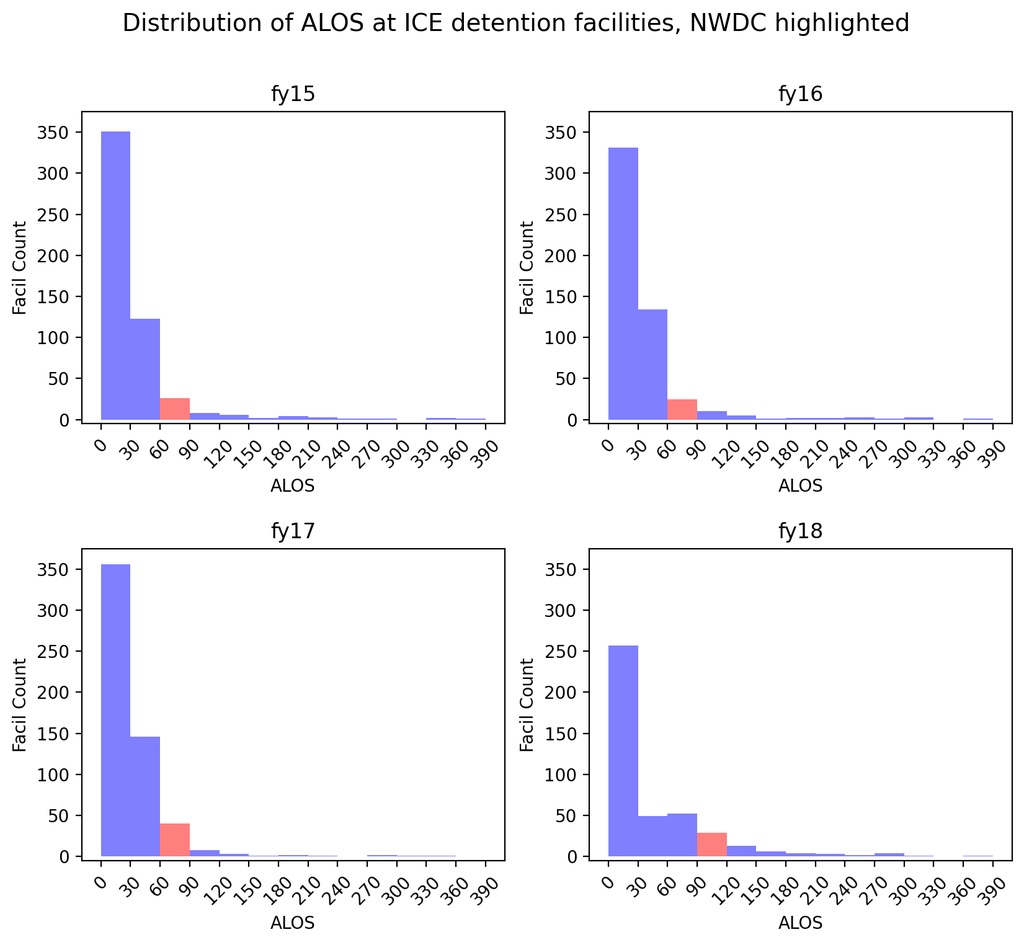

According to ICE's FY2020 Budget Congressional Justification, the national average length of stay (ALOS) in immigration detention was 47.4 days in FY2018.<sup>[6]</sup> The same source also notes, "For those arrested during ICE interior enforcement operations, ALOS was 53.9 days."<sup>[7]</sup>

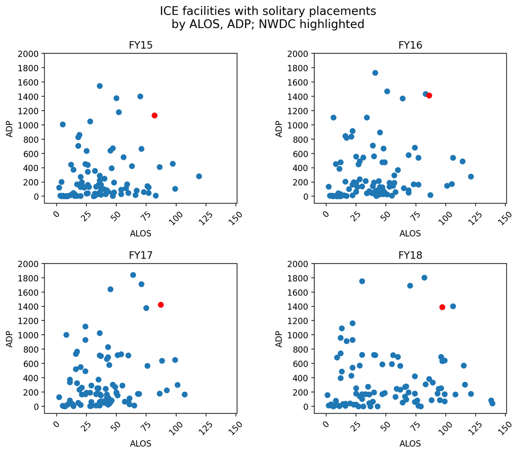

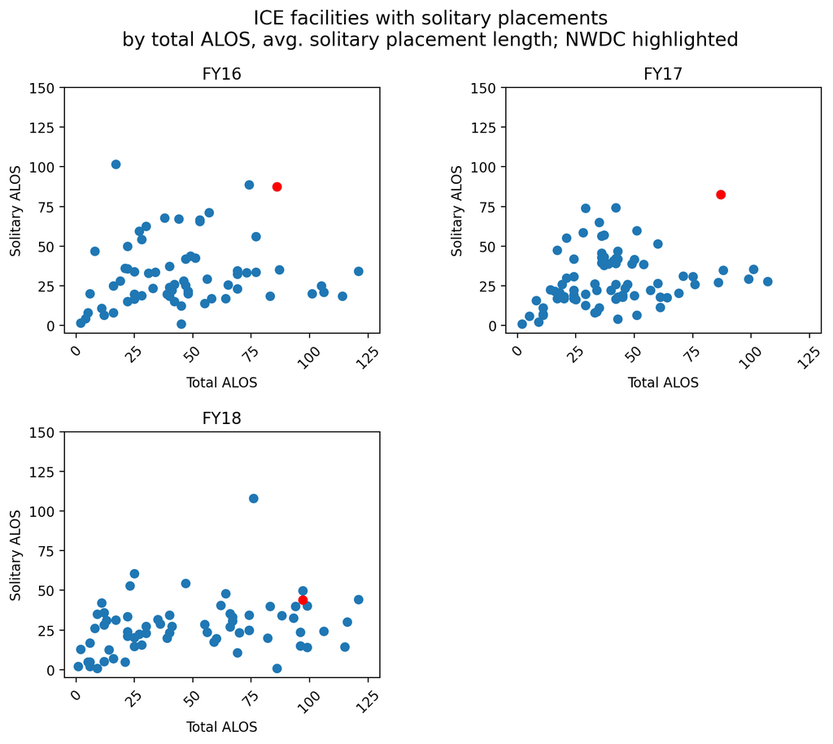

## Notes

<sup>[1]</sup> OIG-17-119, [ICE Field Offices Need to Improve Compliance with Oversight Requirements for Segregation of Detainees with Mental Health Conditions](https://www.oig.dhs.gov/sites/default/files/assets/2017-11/OIG-17-119-Sep17.pdf), September 29, 2017.

<sup>[2]</sup> [ICE 2017 Budget Justification](https://www.thisweekinimmigration.com/uploads/6/9/2/2/69228175/fy17budgetcongressionaljustificationdhs2.pdf), p. 54.

<sup>[3]</sup> OIG-17-119 [ICE Field Offices Need to Improve Compliance with Oversight Requirements for Segregation of Detainees with Mental Health Conditions](https://www.oig.dhs.gov/sites/default/files/assets/2017-11/OIG-17-119-Sep17.pdf) (September 29, 2017)

<sup>[4]</sup> No records are missing "Placement Date" values, and no record has a "Release Date" preceding its "Placement Date".

<sup>[5]</sup> See Section 2.12 "Special Management Units" in ICE’s detention standards manual: https://www.ice.gov/doclib/detention-standards/2011/2-12.pdf

<sup>[6]</sup> See: https://www.dhs.gov/sites/default/files/publications/19_0318_MGMT_CBJ-Immigration-Customs-Enforcement_0.pdf, page 4.

<sup>[7]</sup> Ibid. p. 148.

Published from src/nwdc.pmd using [Pweave](http://mpastell.com/pweave) 0.30.3 on 10-11-2020.